# gebruikersdag

Steven Wink

April 3, 2016

# # Het rechter spectrum van BI

## 1: significantie, 2: visualizatie, 3: groeperen, 4: predictie *** De statistische taal ‘R’ kan aangeroepen worden vanuit Diver. *** Enkele kleine voorbeeldjes over het gebruik van R om meer inzicht in data te krijgen.

# 1: significantie * Het kwantificeren van hoe zeker we zijn over een meting of voorspelling ** Is er een verschil in het alcohol gehalte tussen de verschillende wijn soorten? ** Betekent dit verschil iets? (is het significant)

[output not shown]

[output not shown]

[output not shown]

Om het antwoord te vinden, zouden we simpelweg het gemiddelde kunnen berekenen:

```r
aggregate(Alcohol  ~ wine.class, data = wine.c, FUN = mean)
```

```
##   wine.class  Alcohol
## 1     barolo 13.74475
## 2 grignolino 12.27873
## 3    barbera 13.15375
```

Maar is dit nou anders? Kunnen we deze gemiddelden bij de batch van volgend jaar weer verwachten?

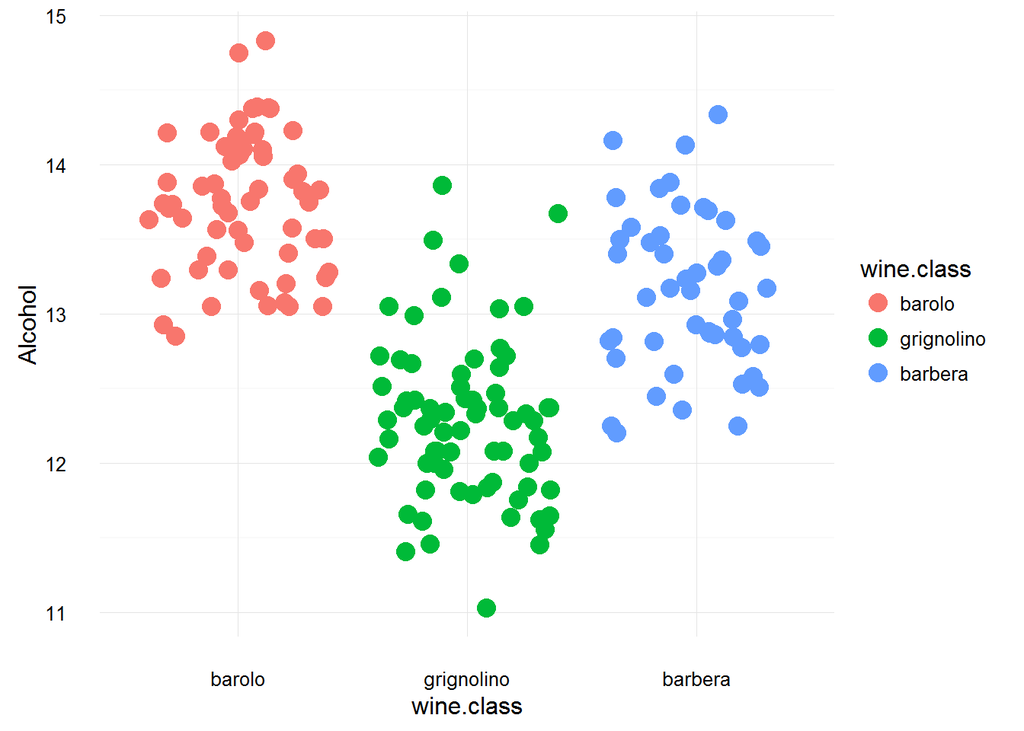

```r
p <- ggplot(data = wine.c, aes( x = wine.class, y = Alcohol )) + geom_jitter(aes(color = wine.class), size = 4) + theme_minimal()
print(p)
```

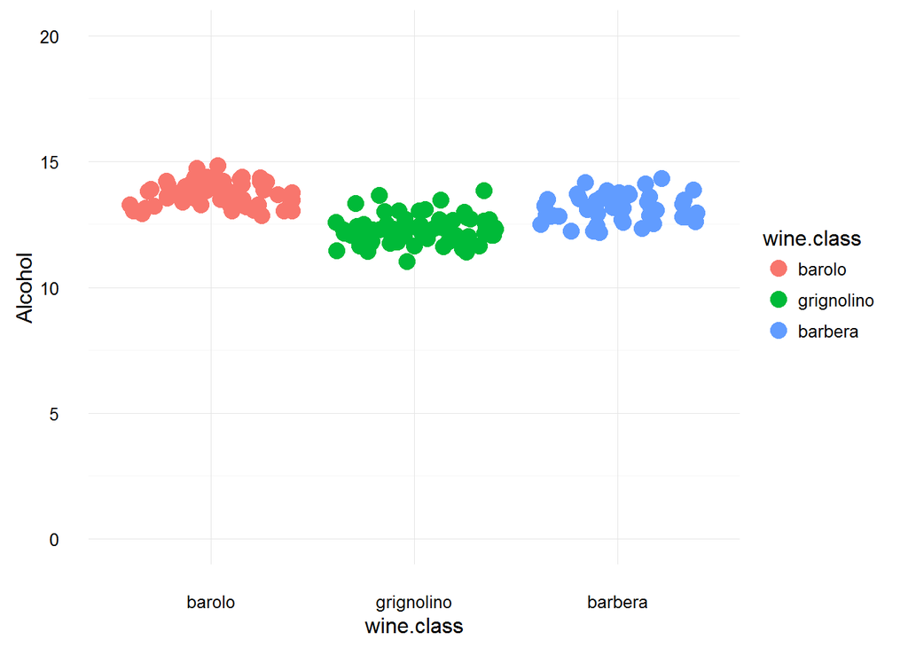

```r
p  +  ylim(c(0,20))
```

```r
lm.out <- lm( Alcohol ~ wine.class, data = wine.c)
summary(lm.out)
```

```
##
## Call:
## lm(formula = Alcohol ~ wine.class, data = wine.c)
##
## Residuals:
##      Min       1Q   Median       3Q      Max
## -1.24873 -0.35200  0.01127  0.34375  1.58127
##
## Coefficients:
##                      Estimate Std. Error t value Pr(>|t|)
## (Intercept)          13.74475    0.06665 206.238  < 2e-16 ***
## wine.classgrignolino -1.46601    0.09018 -16.257  < 2e-16 ***
## wine.classbarbera    -0.59100    0.09950  -5.939 1.51e-08 ***
## ---
## Signif. codes:  0 '***' 0.001 '**' 0.01 '*' 0.05 '.' 0.1 ' ' 1
##
## Residual standard error: 0.5119 on 175 degrees of freedom
## Multiple R-squared:  0.6069, Adjusted R-squared:  0.6024
## F-statistic: 135.1 on 2 and 175 DF,  p-value: < 2.2e-16
```

Welke meting hangt het meest samen met alcohol percentage? Is dit onafhankelijk van het soort druif?

```r
# volgende hoogste correlaties met kwaliteit? hoe verhouden deze zich dan? is er een optimale combinatie van deze?

cor(wine.c[, -14])[,1] # Alcohol is gecoroleerd aan bijvoorbeeld Proline
```

```
##        Alcohol      MalicAcid            Ash         AlcAsh             Mg
##     1.00000000     0.09439694     0.21154460    -0.31023514     0.27079823
##        Phenols           Flav NonFlavPhenols           Proa          Color
##     0.28910112     0.23681493    -0.15592947     0.13669791     0.54636420
##            Hue             OD        Proline
##    -0.07174720     0.07234319     0.64372004
```

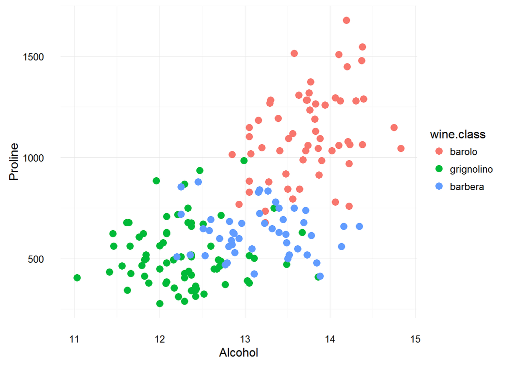

```r
p <- ggplot(data = wine.c, aes( x = Alcohol, y = Proline, color = wine.class )) + geom_point(size= 3) + theme_minimal()
print(p)
```

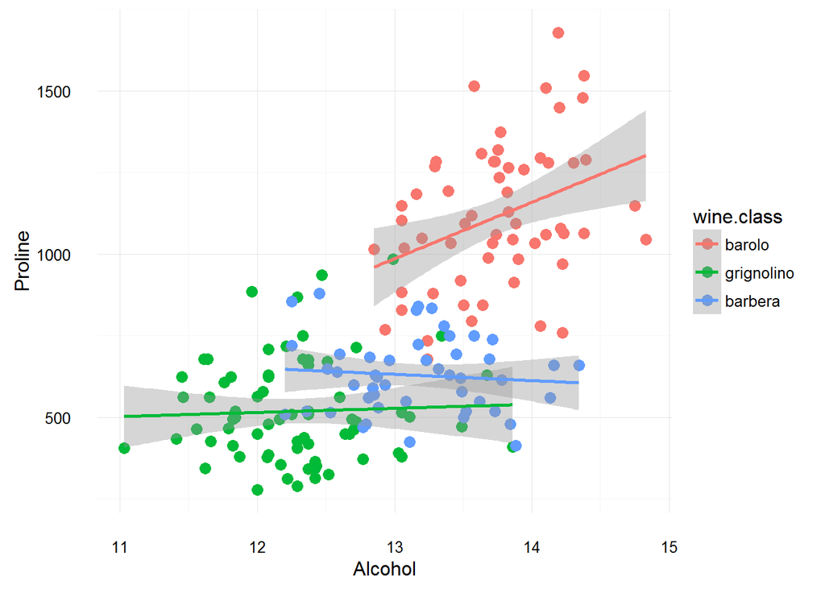

```r
p + geom_smooth(method = 'lm') # voeg een regressielijntje toe
```

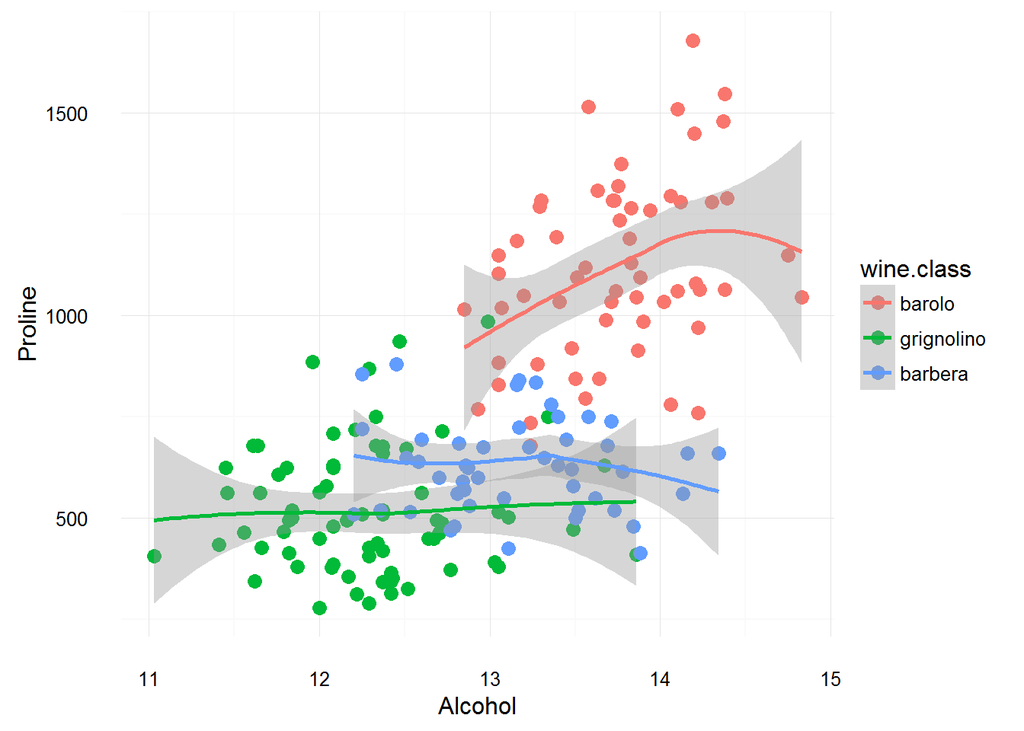

```r
# non linear method
p + geom_smooth(span = 1 ) # voeg een regressielijntje toe
```

# 2: visualizatie & 3: groeperen